# Inductive spatial transfer: experiments

# 1 Design

- Train on one region, predict a second region the model has never seen.
- The two regions carry separate graphs. No edge crosses the boundary.
- Inductive: the test graph did not exist at training time.
- Metric is $R^2 = 1 - \mathrm{SSE}/\mathrm{SST}$ on the held-out region. AUC for classification.
- Arms: OLS, spatial error model (GMM), XGBoost, XGBoost with row-standardised spatial lags of every covariate, GraphSAGE, GraphSAGE with node-level layer normalisation.
- Stochastic arms run 10 to 15 seeds; deterministic arms run once.

# 2 Held-out US states

3,005 counties in the 39 states holding at least 20 counties. Target is county two-party Democratic vote share from 14 demographic and economic covariates. Hold out one state, train on the other 38, predict every county in the held-out state.

Mean over the 39 held-out states.

| Model | R2 | RMSE | MAE |
| --- | --- | --- | --- |
| GraphSAGE | 0.645 | 7.041 | 5.565 |
| GraphSAGE + LayerNorm | 0.617 | 7.332 | 5.729 |
| XGBoost + lags | 0.542 | 8.061 | 6.357 |
| XGBoost | 0.532 | 8.124 | 6.385 |
| OLS | 0.187 | 10.047 | 7.946 |
| SEM | 0.186 | 10.246 | 8.332 |

Paired over states. Percentages are means of per-state change.

| Comparison | R2 difference | p value | States lower error | RMSE pct | MAE pct |
| --- | --- | --- | --- | --- | --- |
| GraphSAGE less XGBoost + lags | 0.103 | 0.001 | 30/39 | 11.944 | 11.442 |

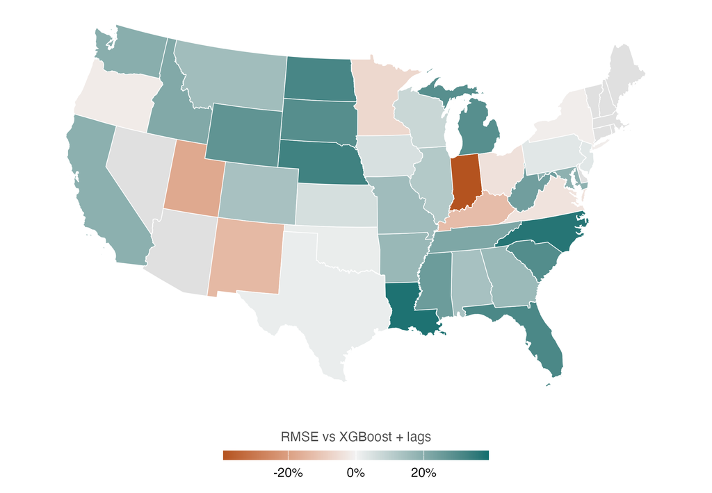

Per-state change in RMSE, GraphSAGE against XGBoost with spatial lags. Grey states hold fewer than 20 counties and were not tested.

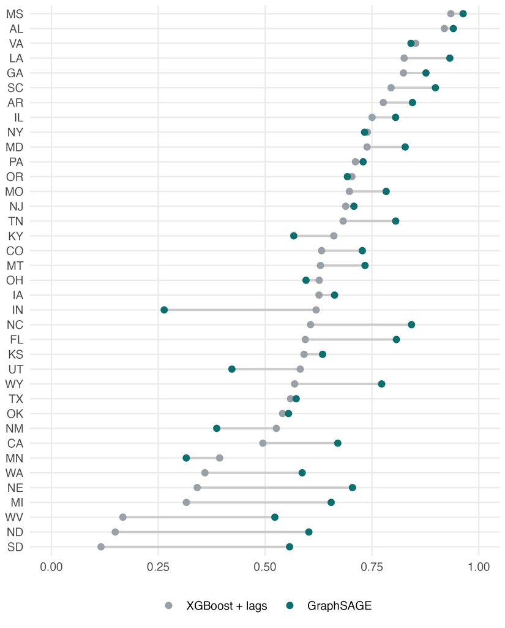

R-squared on each held-out state, ordered by the XGBoost result. Wisconsin and Idaho are below zero for both models and are omitted from the axis.

# 3 Cross-region transfers

Margin is the best GraphSAGE variant less the best arm that uses no graph, both on the held-out region.

Ordered by margin.

| Transfer | GraphSAGE | Best other | Arm | Margin |
| --- | --- | --- | --- | --- |
| County vote share, 39 held-out states | 0.645 | 0.542 | XGBoost + lags | 0.103 |
| Surface temperature, Cedar Rapids to Des Moines | 0.796 | 0.699 | XGBoost + lags | 0.097 |
| Airbnb price, LA to Chicago | 0.630 | 0.588 | XGBoost + lags | 0.042 |
| House price, Ames to King County | 0.307 | 0.267 | OLS | 0.040 |
| Airbnb price, Broward to San Diego | 0.679 | 0.649 | XGBoost | 0.030 |
| Surface temperature, Des Moines to Cedar Rapids | 0.817 | 0.808 | XGBoost + lags | 0.009 |
| Airbnb price, Chicago to LA | 0.623 | 0.632 | OLS | -0.009 |
| 311 response time, Queens to Brooklyn | 0.254 | 0.301 | OLS | -0.047 |
| 311 response time, Brooklyn to Queens | 0.446 | 0.494 | XGBoost | -0.048 |
| Airbnb price, San Diego to Broward | 0.484 | 0.540 | XGBoost | -0.055 |
| Diabetes prevalence, CA to WV | 0.741 | 0.801 | XGBoost + lags | -0.060 |
| Airbnb reviews, Broward to San Diego | 0.198 | 0.271 | XGBoost | -0.074 |
| Tree diameter, Brooklyn to Queens | 0.246 | 0.334 | XGBoost | -0.088 |
| Tree diameter, Queens to Brooklyn | 0.167 | 0.275 | OLS | -0.109 |

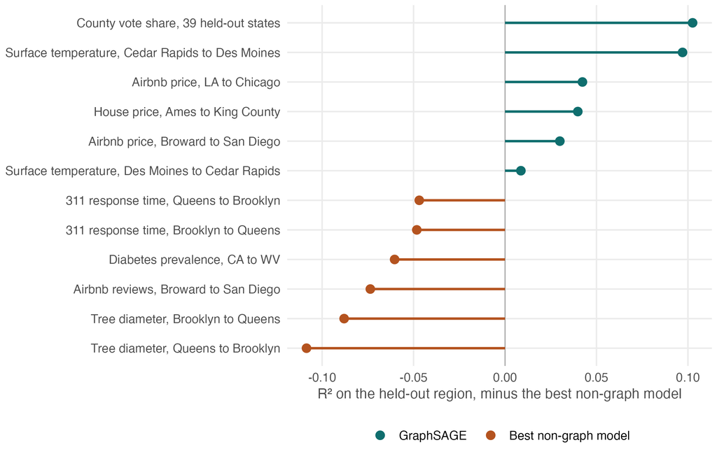

## 3.1 Classification

Same two cities and the same predictors as the surface temperature transfer, with land cover class as the target.

Des Moines to Cedar Rapids, land cover class.

| Model | AUC |
| --- | --- |
| GraphSAGE + LayerNorm | 0.9277 |
| Logistic | 0.9267 |
| GraphSAGE | 0.9191 |
| XGBoost + lags | 0.8893 |
| XGBoost | 0.8775 |